# Análise de dados de implantes dentários: Odontologia PUCRS

Rodrigo Citton P. dos Reis

Junho de 2018

```r
# ----------------------------------
# Remove objetos do R

rm(list = ls(all = TRUE))

# ----------------------------------
# Carrega pacotes do R

library(readxl)
library(ggplot2)
library(ggpubr)
library(reshape2)
library(data.table)
library(dplyr)
library(stringr)
library(compareGroups)
library(tidyr)
library(knitr)
library(lme4)
library(lmerTest)
library(bbmle)
library(stargazer)
library(knitr)
library(ggeffects)

# ----------------------------------
# Declara funções do R

# Remove acentos
Unaccent <- function(text) {
  text <- gsub("['`^~\"]", " ", text)
  text <- iconv(text, to="ASCII//TRANSLIT//IGNORE")
  text <- gsub("['`^~\"]", "", text)
  return(text)
}

# ----------------------------------
# Carrega os dados

# dados <- read_excel("C:\\Users\\RODRIGO\\Documents\\Odontologia\\Mauricio\\data\\dados_mauricio.xlsx")
# dados <- read_excel("C:\\Users\\Rodrigo\\Documents\\Odontologia\\Mauricio\\data\\dados_mauricio.xlsx")
dados <- read_excel("C:\\Users\\Rodrigo\\Documents\\Odontologia\\Mauricio\\data\\dados_mauricio_2.xlsx")

dados <- data.frame(dados)

# ----------------------------------
# Formata nomes das variáveis

names(dados) <- Unaccent(names(dados))
names(dados) <- str_to_lower(names(dados))
# names(dados) <- str_replace_all(names(dados), "\\s", "_")
names(dados) <- str_replace_all(names(dados), "bl", "0") # bl vira 0
names(dados) <- str_replace_all(names(dados), "t1", "1") # t1 vira 1
names(dados) <- str_replace_all(names(dados), "t3", "2") # t3 vira 2
names(dados) <- str_replace_all(names(dados), ".cinza", "_cinza")
names(dados) <- str_replace_all(names(dados), ".pad", "_pad")
names(dados) <- str_replace_all(names(dados), ".variacao", "_variacao")

# ----------------------------------
# Formata variáveis

dados$bitestrip <- factor(dados$bitestrip, labels = c("Não", "Sim"))
dados$ar.bruxismo <- factor(dados$ar.bruxismo, labels = c("Não", "Sim"))
dados$provisorio <- factor(dados$provisorio, labels = c("Não", "Sim"))
dados$arch <- factor(dados$arch, labels = c("Maxila", "Mandíbula"))
dados$sex <- factor(dados$sex, labels = c("Masculino", "Feminino"))
names(dados)[names(dados) == "sex"] <- "sexo"
names(dados)[names(dados) == "idade.em.0"] <- "idade"

# ----------------------------------
# Wide to long

tidier <- dados %>%
  gather(key, valor, -patient, -sexo, -idade, -bitestrip, -ar.bruxismo, -forca.de.mordida, -id.implante, -provisorio, -arch)

tidy <- tidier %>%
  separate(key, into = c("var", "type", "time"), sep = "\\.")

tidy2 <- tidy %>%
  spread(var, valor)

dados.longo <- tidy2 %>%
  arrange(patient, id.implante, type, time)

# head(dados.longo[c('id.implante', 'patient','time', 'type')], 20)

dados.longo$time <- factor(dados.longo$time, labels = c("0", "1", "2"))

# ----------------------------------
# Long to wide-wide

vars <- c("sexo", "idade", "bitestrip",
          "ar.bruxismo", "forca.de.mordida",
          "provisorio", "arch", "patient")
# dados[vars]
dados.wide.wide <- dados[duplicated(dados[vars]),]
```

## Introdução

O presente relatório tem como objetivo apresentar os resultados da análise do conjunto de dados de implantes dentários de 30 pacientes em três tempos de avaliação (linha de base, um ano após a linha de base e três anos após a linha de base).

A análise de dados pretende:

Os possíveis fatores associados considerados neste estudo foram todos medidos na linha de base, e são listados a seguir:

- **Idade do paciente**;
- **Sexo do paciente**;
- **Força de mordida**;
- **Presença de bruxismo**;
- **Utilização de provisório**;
- **Arcada dos implantes**.

## Métodos

As variáveis contínuas foram apresentadas por médias e desvios padrão. As variáveis categóricas foram apresentadas por frequências absolutas e percentuais. Para as análises do estudo, a variável tempo foi codificada da seguinte forma:

- Linha de base: 0;
- Um ano após a linha de base: 1;
- Três anos após a linha de base: 2.

Para avaliar a relação entre as variáveis resposta e possíveis fatores associados, ao longo do tempo, foi utilizado o modelo de regressão linear de efeitos mistos (também conhecido como modelo de efeitos mistos, modelo linear misto ou modelo de efeitos aleatórios). O modelo linear misto é uma generalização do modelo de regressão linear apropriada para quando analisamos dados correlacionados (a suposição de independência não é atendida, ou não é verossímil). Isto ocorre em situações que temos observações feitas no mesmo indivíduo (medidas repetidas ao longo do tempo dos implantes de cada paciente; também conhecido como dados longitudinais), ou unidades naturalmente agrupadas (implantes de um mesmo paciente; também conhecido como dados aninhados ou estrutura multinível). A presença de correlação entre as observações (dados dependentes) pode ser vista também como a presença de heterogeneidade não-observada (não-mensurada) entre as unidades de estudo.

A utilização usual do modelo de regressão linear para esses casos ignora tal correlação porque trata as observações como independentes (Draper and Smith 1998), obtendo inferências menos confiáveis. Em particular, as estimativas dos erros-padrão dos coeficientes do modelo ficam viciadas (Diggle, Liang, and Zeger 1994).

O modelo linear misto acomoda a estrutura de dependência entre as observações através da inclusão de efeitos aleatórios. O modelo de efeitos aleatórios permite não somente descrever a tendência temporal levando em conta a correlação que existe entre medidas sucessivas como também estimar a variação na medida basal e a taxa de mudança ao longo do tempo (Fausto et al. 2008).

Com esta abordagem, foi avaliado se:

- A média da variável resposta varia ao longo do tempo (efeito principal do fator tempo);
- A variação da variável na linha de base é diferente para os diferentes níveis dos possíveis fatores associados (efeito principal do fator associado);
- A taxa de mudança ao longo do tempo é diferente para diferentes níveis dos possíveis fatores associados (efeito de interação entre os fatores tempo e fator associado).

Os modelos foram ajustados separadamente para cada variável resposta. Incialmente, foi ajustado um modelo para cada fator associado e o fator tempo. Em seguida, foram ajustados modelos considerando mútliplos fatores associados e tempo. Por fim, foram ajustados modelos com efeitos de interação entre o tempo e fatores associados.

A estrutura de dependência entre as observações foi especificada considerando os fatores paciente, implante *aninhado* em paciente e lado *aninhado* em implante e paciente como efeitos aleatórios. A estrutura aninhada (multinível) das observações pode ser exemplificada pela figura a seguir.

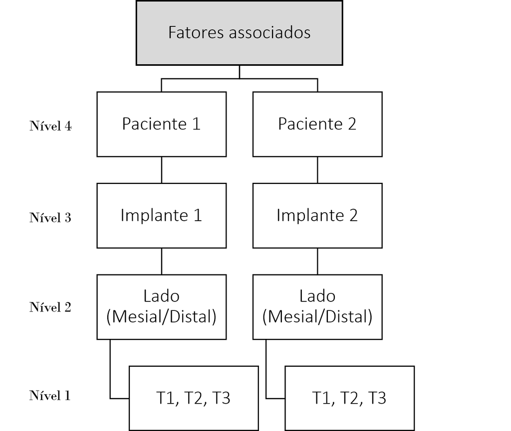

Observações aninhadas ou estrutura multinível para os dados de implantes dentários.

Foi utilizado o método da máxima verossimilhança restrita (*restricted maximum likelihood*; REML) para a estimação dos parâmetros do modelo linear misto. A signficância dos efeitos foi avaliada pelo teste F da análise de variância (ANOVA). A adequação da especificação dos efeitos aleatórios foi avaliada pelo critério de informação de Akaike (AIC). A especificação descrita anteriormente se mostrou mais adequada para todos os modelos ajustados. As suposições do modelo foram avaliadas por métodos gráficos (gráficos dos resíduos dos modelos) e não foram percebidas graves violações para todos os modelos ajustados. O nível de significância utilizado foi 0,05.

### Implementação computacional

A análise de dados foi realizada com a linguagem de programação `R` versão 3.4.3 (R Core Team 2017). Além disso, foram utilizados os seguintes pacotes do `R`:

- `compareGroups` (Subirana, Sanz, and Vila 2014) e `ggplot2` (Wickham 2009) para a análise descritiva.
- `lme4` (Bates et al. 2015) e `lmerTest` (Kuznetsova, Brockhoff, and Christensen 2017) para a análise de regressão via modelo linear misto.
- `rmarkdown` (Allaire et al. 2016), `stargazer` (Hlavac 2018) e `knitr` (Xie 2018) para a elaboração do relatório.

## Resultados

### Análise descritiva

```r
# ----------------------------------
# Conhecendo os dados

vars <- c("sexo", "idade", "bitestrip",
          "ar.bruxismo", "forca.de.mordida",
          "provisorio", "arch")

res <- compareGroups(data = dados.wide.wide[, vars],
                     method = NA)
table_bl_0001 <- createTable(res, show.p.overall = FALSE)

res <- compareGroups(data = dados[, vars],
                     method = NA)
table_bl_01 <- createTable(res, show.p.overall = FALSE)
# export2md(table_bl_01,
#           caption = "Resumo das variáveis do estudo da linha de base.")

dados.longo <- data.frame(dados.longo)

vars <- c("patient", "id.implante", "ar.bruxismo", "provisorio",
          "type", "time", "coef_variacao",
          "contraste", "correlacao", "desv_pad",
          "entropia", "med_cinza", "sma")

res <- compareGroups(time ~ . - type - patient - id.implante - ar.bruxismo - provisorio,
                     data = dados.longo[vars],
                     subset = type == "mesial",
                     method = 1)
table_times_mesial_01 <- createTable(res, show.p.overall = FALSE)
# export2md(table_times_mesial_01,
#           caption = "Resumo das variáveis do estudo (mesial) por tempo de medição.",
#           header.labels = c(p.overall = "p-value"))

res <- compareGroups(time ~ . - type - patient - id.implante - ar.bruxismo - provisorio,
                     data = dados.longo[vars],
                     subset = type == "distal",
                     method = 1)
table_times_distal_01 <- createTable(res, show.p.overall = FALSE)
# export2md(table_times_distal_01,
#           caption = "Resumo das variáveis do estudo (distal) por tempo de medição.",
#           header.labels = c(p.overall = "p-value"))

res <- compareGroups(time ~ . - type - patient - id.implante - ar.bruxismo - provisorio,
                     data = dados.longo[vars],
                     # subset = type == "distal",
                     method = 1)
table_times_01 <- createTable(res, show.p.overall = FALSE)
# export2md(table_times_01,
#           caption = "Resumo das variáveis do estudo (distal e mesial) por tempo de medição.",
#           header.labels = c(p.overall = "p-value"))
```

A tabela a seguir apresenta as estatísticas descritivas das características dos pacientes do estudo na linha de base.

```r
export2md(table_bl_0001,
          caption = "Resumo das variáveis do estudo da linha de base (paciente).")
```

Resumo das variáveis do estudo da linha de base (paciente).

|  | [ALL] | N |
| --- | --- | --- |
|  | N=30 |  |
| sexo: |  | 30 |
| Masculino | 8 (26.7%) |  |
| Feminino | 22 (73.3%) |  |
| idade | 62.0 (7.84) | 30 |
| bitestrip: |  | 21 |
| Não | 16 (76.2%) |  |
| Sim | 5 (23.8%) |  |
| ar.bruxismo: |  | 30 |
| Não | 22 (73.3%) |  |
| Sim | 8 (26.7%) |  |
| forca.de.mordida | 471 (142) | 30 |
| provisorio: |  | 30 |
| Não | 20 (66.7%) |  |
| Sim | 10 (33.3%) |  |
| arch: |  | 30 |
| Maxila | 12 (40.0%) |  |
| Mandíbula | 18 (60.0%) |  |

A próxima tabela apresenta as estatísticas descritivas das variáveis respostas por tempo de avaliação, medidas pelo lado mesial.

```r
export2md(table_times_mesial_01,
          caption = "Resumo das variáveis do estudo (mesial) por tempo de medição (implante).",
          header.labels = c(p.overall = "p-value"))
```

Resumo das variáveis do estudo (mesial) por tempo de medição (implante).

|  | 0 | 1 | 2 |
| --- | --- | --- | --- |
|  | N=59 | N=59 | N=41 |
| coef_variacao | 0.09 (0.06) | 0.09 (0.04) | 0.07 (0.03) |
| contraste | 6.05 (3.63) | 5.90 (4.39) | 5.43 (4.02) |
| correlacao | 0.03 (0.02) | 0.03 (0.03) | 0.03 (0.03) |
| desv_pad | 7.74 (3.17) | 7.85 (3.73) | 7.01 (2.79) |
| entropia | 4.57 (0.38) | 4.55 (0.46) | 4.50 (0.43) |
| med_cinza | 96.4 (36.2) | 98.4 (34.8) | 103 (37.5) |
| sma | 0.01 (0.01) | 0.02 (0.01) | 0.02 (0.01) |

A próxima tabela apresenta as estatísticas descritivas das variáveis respostas por tempo de avaliação, medidas pelo lado distal.

```r
export2md(table_times_distal_01,
          caption = "Resumo das variáveis do estudo (distal) por tempo de medição (implante).",
          header.labels = c(p.overall = "p-value"))
```

Resumo das variáveis do estudo (distal) por tempo de medição (implante).

|  | 0 | 1 | 2 |
| --- | --- | --- | --- |
|  | N=59 | N=58 | N=43 |
| coef_variacao | 0.08 (0.05) | 0.07 (0.03) | 0.07 (0.04) |
| contraste | 6.24 (4.31) | 5.25 (2.64) | 5.47 (3.69) |
| correlacao | 0.03 (0.03) | 0.03 (0.02) | 0.03 (0.03) |
| desv_pad | 7.31 (3.32) | 6.78 (2.52) | 7.07 (3.01) |
| entropia | 4.49 (0.43) | 4.48 (0.39) | 4.48 (0.44) |
| med_cinza | 96.0 (29.1) | 102 (28.7) | 110 (32.6) |
| sma | 0.02 (0.01) | 0.02 (0.01) | 0.02 (0.01) |

A próxima tabela apresenta as estatísticas descritivas das variáveis respostas por tempo de avaliação (lados mesial e distal).

```r
export2md(table_times_01,
          caption = "Resumo das variáveis do estudo (mesial e distal) por tempo de medição (implante).",
          header.labels = c(p.overall = "p-value"))
```

Resumo das variáveis do estudo (mesial e distal) por tempo de medição (implante).

|  | 0 | 1 | 2 |
| --- | --- | --- | --- |
|  | N=118 | N=117 | N=84 |
| coef_variacao | 0.09 (0.05) | 0.08 (0.04) | 0.07 (0.03) |
| contraste | 6.15 (3.97) | 5.57 (3.62) | 5.45 (3.83) |
| correlacao | 0.03 (0.03) | 0.03 (0.03) | 0.03 (0.03) |
| desv_pad | 7.52 (3.24) | 7.32 (3.22) | 7.04 (2.89) |
| entropia | 4.53 (0.41) | 4.51 (0.43) | 4.49 (0.43) |
| med_cinza | 96.2 (32.7) | 100 (31.8) | 106 (35.1) |
| sma | 0.02 (0.01) | 0.02 (0.01) | 0.02 (0.01) |

### Relação entre fatores associados e variáveis resposta

#### Média de cinza

```r
mod5.1 <- lmer(
  med_cinza ~ time + forca.de.mordida +
    (1 | patient:id.implante:type) +
    (1 | patient:id.implante) +
    (1 | patient),
  data = dados.longo)
# summary(mod5.1)

mod5.2 <- lmer(
  med_cinza ~ time + idade +
    (1 | patient:id.implante:type) +
    (1 | patient:id.implante) +
    (1 | patient),
  data = dados.longo)
# summary(mod5.2)

mod5.3 <- lmer(
  med_cinza ~ time + sexo +
    (1 | patient:id.implante:type) +
    (1 | patient:id.implante) +
    (1 | patient),
  data = dados.longo)
# summary(mod5.3)

mod5.4 <- lmer(
  med_cinza ~ time + ar.bruxismo +
    (1 | patient:id.implante:type) +
    (1 | patient:id.implante) +
    (1 | patient),
  data = dados.longo)
# summary(mod5.4)

mod5.5 <- lmer(
  med_cinza ~ time + provisorio +
    (1 | patient:id.implante:type) +
    (1 | patient:id.implante) +
    (1 | patient),
  data = dados.longo)
# summary(mod5.5)

mod5.6 <- lmer(
  med_cinza ~ time + arch +
    (1 | patient:id.implante:type) +
    (1 | patient:id.implante) +
    (1 | patient),
  data = dados.longo)
# summary(mod5.6)

class(mod5.1) <- "lmerMod"
class(mod5.2) <- "lmerMod"
class(mod5.3) <- "lmerMod"
class(mod5.4) <- "lmerMod"
class(mod5.5) <- "lmerMod"
class(mod5.6) <- "lmerMod"
```

A tabela a seguir apresenta os resultados dos modelos do tempo e cada fator associado. A tabela apresenta os coeficientes do modelo de regressão estimados.

```r
stargazer(mod5.1, mod5.2, mod5.3, mod5.4, mod5.5, mod5.6,
          type = "html",
          ci = TRUE,
          # report = "vct*",
          dep.var.caption = "Variável resposta",
          dep.var.labels = "Média de cinza",
          omit.stat = c("aic", "bic", "ll"),
          title = "Estimativas dos efeitos fixos dos modelos simples.")
```

**Estimativas dos efeitos fixos dos modelos simples.**

|  | Variável resposta |  |  |  |  |  |
| --- | --- | --- | --- | --- | --- | --- |
|  | Média de cinza |  |  |  |  |  |
|  | (1) | (2) | (3) | (4) | (5) | (6) |
| time1 | 4.190** | 4.183** | 4.190** | 4.189** | 4.199** | 4.191** |
|  | (0.364, 8.016) | (0.355, 8.011) | (0.363, 8.017) | (0.362, 8.016) | (0.372, 8.026) | (0.364, 8.019) |
| time2 | 9.155*** | 9.138*** | 9.161*** | 9.140*** | 9.081*** | 9.178*** |
|  | (4.789, 13.521) | (4.768, 13.508) | (4.791, 13.532) | (4.771, 13.510) | (4.712, 13.450) | (4.807, 13.549) |
| forca.de.mordida | 0.096*** |  |  |  |  |  |
|  | (0.041, 0.150) |  |  |  |  |  |
| idade |  | -1.241** |  |  |  |  |
|  |  | (-2.376, -0.105) |  |  |  |  |
| sexoFeminino |  |  | -6.492 |  |  |  |
|  |  |  | (-27.706, 14.721) |  |  |  |
| ar.bruxismoSim |  |  |  | -8.319 |  |  |
|  |  |  |  | (-29.549, 12.912) |  |  |
| provisorioSim |  |  |  |  | 16.420* |  |
|  |  |  |  |  | (-0.556, 33.396) |  |
| archMandíbula |  |  |  |  |  | 9.323 |
|  |  |  |  |  |  | (-6.395, 25.040) |
| Constant | 51.023*** | 172.271*** | 100.214*** | 97.642*** | 90.139*** | 90.108*** |
|  | (24.323, 77.723) | (101.403, 243.139) | (81.940, 118.489) | (86.568, 108.716) | (79.631, 100.646) | (76.930, 103.287) |
| Observations | 319 | 319 | 319 | 319 | 319 | 319 |
| *Note:* | p<0.1; p<0.05; p<0.01 |  |  |  |  |  |

```r
mod6.0 <- lmer(
  med_cinza ~ 1 +
    (1 | patient:id.implante:type) +
    (1 | patient:id.implante) +
    (1 | patient),
  data = dados.longo)
# summary(mod6.0)

mod6.1 <- lmer(
  med_cinza ~ time + forca.de.mordida +
    (1 | patient:id.implante:type) +
    (1 | patient:id.implante) +
    (1 | patient),
  data = dados.longo)
# summary(mod6.1)

mod6.2 <- lmer(
  med_cinza ~ time + forca.de.mordida + idade + sexo +
    (1 | patient:id.implante:type) +
    (1 | patient:id.implante) +
    (1 | patient),
  data = dados.longo)

mod6.3 <- lmer(
  med_cinza ~ time + forca.de.mordida + idade + sexo + ar.bruxismo + provisorio + arch +
    (1 | patient:id.implante:type) +
    (1 | patient:id.implante) +
    (1 | patient),
  data = dados.longo)

mc.anova <- anova(mod6.0, mod6.1, mod6.2, mod6.3)

class(mod6.0) <- "lmerMod"
class(mod6.1) <- "lmerMod"
class(mod6.2) <- "lmerMod"
class(mod6.3) <- "lmerMod"
```

```r
stargazer(mod6.0, mod6.1, mod6.2, mod6.3,
          type = "html",
          ci = TRUE,
          # report = "vct*",
          dep.var.caption = "Variável resposta",
          dep.var.labels = "Média de cinza",
          omit.stat = c("aic", "bic", "ll"),
          title = "Estimativas dos efeitos fixos dos modelos nulo (1), tempo e força de mordida (2), (2) ajustado por idade e sexo, (3) ajustado por bruxismo, provisório e arcada.")
```

**Estimativas dos efeitos fixos dos modelos nulo (1), tempo e força de mordida (2), (2) ajustado por idade e sexo, (3) ajustado por bruxismo, provisório e arcada.**

|  | Variável resposta |  |  |  |
| --- | --- | --- | --- | --- |
|  | Média de cinza |  |  |  |
|  | (1) | (2) | (3) | (4) |
| time1 |  | 4.190** | 4.183** | 4.198** |
|  |  | (0.364, 8.016) | (0.357, 8.009) | (0.371, 8.025) |
| time2 |  | 9.155*** | 9.120*** | 9.117*** |
|  |  | (4.789, 13.521) | (4.753, 13.487) | (4.749, 13.485) |
| forca.de.mordida |  | 0.096*** | 0.097*** | 0.070* |
|  |  | (0.041, 0.150) | (0.027, 0.167) | (-0.006, 0.146) |
| idade |  |  | -0.530 | -0.624 |
|  |  |  | (-1.693, 0.633) | (-1.791, 0.543) |
| sexoFeminino |  |  | 7.994 | 3.223 |
|  |  |  | (-13.318, 29.306) | (-18.741, 25.186) |
| ar.bruxismoSim |  |  |  | -6.634 |
|  |  |  |  | (-25.399, 12.132) |
| provisorioSim |  |  |  | 13.524 |
|  |  |  |  | (-3.841, 30.889) |
| archMandíbula |  |  |  | 11.298 |
|  |  |  |  | (-3.765, 26.361) |
| Constant | 99.200*** | 51.023*** | 77.549 | 90.226* |
|  | (89.891, 108.508) | (24.323, 77.723) | (-21.956, 177.055) | (-10.895, 191.347) |
| Observations | 319 | 319 | 319 | 319 |
| *Note:* | p<0.1; p<0.05; p<0.01 |  |  |  |

Os resultados apresentam significância dos fatores tempo e força de mordida. Após o ajuste por idade e sexo, estes fatores permanecem significativos. Após o ajuste por outros fatores associados, a força de mordida apresenta significância limítrofe (*borderline*; valor de p entre 0,05 e 0,10). Termos de interação foram testados, porém não apresentaram significância estatística.

A tabela a seguir apresenta a comparação entre os modelos. O modelo (2) foi estatisticamente diferente do modelo nulo (1), e os modelos (3) e (4) não apresentaram diferença estatisticamente significativa para o modelo (2).

```r
options(knitr.kable.NA = '')

row.names(mc.anova) <- c("(1)", "(2)", "(3)", "(4)")

kable(x = mc.anova, digits = 3, format = "pandoc",
      caption = "Comparação entre modelos.",
      row.names = TRUE,
      col.names = c("gl", "AIC", "BIC", "log-veros.", "Desvio", "Qui-quadrado", "gl", "valor p"))
```

Comparação entre modelos.

|  | gl | AIC | BIC | log-veros. | Desvio | Qui-quadrado | gl | valor p |
| --- | --- | --- | --- | --- | --- | --- | --- | --- |
| (1) | 5 | 2868.177 | 2887.003 | -1429.088 | 2858.177 |  |  |  |
| (2) | 8 | 2847.205 | 2877.327 | -1415.603 | 2831.205 | 26.972 | 3 | 0.000 |
| (3) | 10 | 2849.134 | 2886.786 | -1414.567 | 2829.134 | 2.072 | 2 | 0.355 |
| (4) | 13 | 2850.939 | 2899.886 | -1412.469 | 2824.939 | 4.195 | 3 | 0.241 |

Com base nos resultados do modelo, podemos concluir que:

- Após um ano da linha de base, em média, o nível da média de cinza aumenta 4.19 pixels **(esta unidade está correta?)**.
- Após três anos da linha de base, em média, o nível da média de cinza aumenta 9.15 pixels.
- A cada aumento de uma unidade (um Newton?) na força de mordida, em média, o nível da média de cinza aumenta 0.1 pixel.

Estes resultados podem ser visualizados pelo gráfico de médias estimadas na figura a seguir.

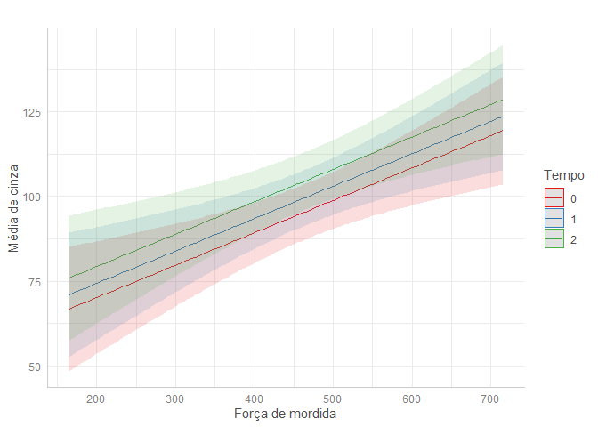

Média ajustadas de nível de média de cinza pelo modelo (2).

```r
mydf <- ggeffect(mod6.1, terms = c("forca.de.mordida", "time"))

plot(mydf) +
  labs(x = "Força de mordida", y = "Média de cinza", color = "Tempo") +
  ggtitle("")
```

## Referências

Allaire, JJ, Joe Cheng, Yihui Xie, Jonathan McPherson, Winston Chang, Jeff Allen, Hadley Wickham, Aron Atkins, and Rob Hyndman. 2016. *Rmarkdown: Dynamic Documents for R*. https://CRAN.R-project.org/package=rmarkdown.

Bates, Douglas, Martin Mächler, Ben Bolker, and Steve Walker. 2015. “Fitting Linear Mixed-Effects Models Using lme4.” *Journal of Statistical Software* 67 (1): 1–48. https://doi.org/10.18637/jss.v067.i01.

Diggle, P. J., K-Y. Liang, and S. L. Zeger. 1994. *Analysis of Longitudinal Data*. Oxford: Clarendon Press.

Draper, N., and H. Smith. 1998. *Applied Regression Analysis*. 3rd ed. New York: John Wiley; Sons.

Fausto, M. A., M. Carneiro, C. M. F. Antunes, J. A. Pinto, and E. A. Colosimo. 2008. “O Modelo de Regressão Linear Misto Para Dados Longitudinais: Uma Aplicação Na Análise de Dados Antropométricos Desbalanceados.” *Cadernos de Saúde Pública* 24 (March): 513–24. http://www.scielo.br/scielo.php?script=sci_arttext&pid=S0102-311X2008000300005&nrm=iso.

Hlavac, Marek. 2018. *Stargazer: Well-Formatted Regression and Summary Statistics Tables*. Bratislava, Slovakia: Central European Labour Studies Institute (CELSI). https://CRAN.R-project.org/package=stargazer.

Kuznetsova, Alexandra, Per B. Brockhoff, and Rune H. B. Christensen. 2017. “lmerTest Package: Tests in Linear Mixed Effects Models.” *Journal of Statistical Software* 82 (13): 1–26. https://doi.org/10.18637/jss.v082.i13.

R Core Team. 2017. *R: A Language and Environment for Statistical Computing*. Vienna, Austria: R Foundation for Statistical Computing. https://www.R-project.org/.

Subirana, Isaac, Héctor Sanz, and Joan Vila. 2014. “Building Bivariate Tables: The compareGroups Package for R.” *Journal of Statistical Software* 57 (12): 1–16. http://www.jstatsoft.org/v57/i12/.

Wickham, Hadley. 2009. *Ggplot2: Elegant Graphics for Data Analysis*. Springer-Verlag New York. http://ggplot2.org.

Xie, Yihui. 2018. *Knitr: A General-Purpose Package for Dynamic Report Generation in R*. https://yihui.name/knitr/.